# L20

# Machine Learning

- ML ≔ how to acquire a model from data / experience
  - Learning parameters (eg: probabilities)
  - Learning structure (eg: BN graphs)
  - Learning hidden concepts (eg: clustering)
- Given training data ≙ example data points and their actual values
- Goal ≙ build model based on training data that outputs results in a similar fashion

## Types of Learning Problems

- Supervised learning ≙ correct answers for each training instance
  - Classification ≙ learning predictor with discrete outputs
  - Regression ≙ learning predictor with real-valued outputs
- Reinforcement learning ≙ reward sequence, no correct answers
- Unsupervised learning ≙ ‘just make sense of the data’

## Classification

- Dataset ≔ each data point, $x$, is associated with some label (aka class), $y$
- Goal ≙ given inputs $x$, write alg to predict labels $y$
- Workflow:
  - $x$ given
  - Extract features from input ≙ attributes of the input that characterize $x$ and hopefully help with classification
  - Run some machine learning alg on the features
  - Output a predicted label $y$

### Model-based Approach

- Build a model (eg: BN) where both the labels and features are random variables
- Instantiate any observed features
- Query for the distribution of the label conditioned on the features
- Challenges: how to structure BN / how to learn parameters

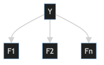

- $Y$ ≔ the label
- $\{F_{1},F_{2},{\dots}F_{n}\}$ ≔ the $n$ features
- Prior ≔ $\mathbb{P}(Y)$
- Generate a table per feature $\mathbb{P}(F_{i}|Y)$
  - Collectively called ‘parameters’; denoted as ${\theta}$
- Training ≙ use the training dataset to estimate the probability tables:
  1. Estimate $\mathbb{P}(Y)$ ≙ how often does each label occur
  2. Estimate $\mathbb{P}(F_{i}|Y)$ ≙ how does the label affect the feature
- Classification ≙ instantiate all features given the input features as evidence
  1. Derive features from sample
  2. Query for $\mathbb{P}(Y|F_{1},F_{2},{\dots},F_{n})$ ≙ probability of label, given all the input features
     - Use an inference alg (eg: variable elimination) to compute this

### Naive Bayes

1. Extract features
2. Generate BN
3. Get joint probability of label and evidence for each label $\mathbb{P}(Y,f_{1},{\dots},f_{n})$
4. Sum to get probability of evidence
5. Normalize
6. Return the $y$ with maximal probability
   - Can restrict to a confidence bound
- Good because returns exact confidence bound for every possible $y$
- Generally $\mathbb{P}(Y,F_{1},{\dots}F_{n})=\mathbb{P}(Y)\prod_{i}\mathbb{P}(F_{i}|Y)$
  - Works because features are assumed to be independent
  - $n\times|F|\times|Y|$ parameters (linear in $n$)

#### Bag-of-words Model

- Each feature is identically distributed
- All features share the same conditional probs $\mathbb{P}(W|Y)$

## Parameter Estimation

- Estimating the distribution of a random variable
- Elicitation ≙ ask a human
- Empirically ≙ use training data

### Maximum Likelihood

- Chose the ${\theta}$ value that maximizes the probability of the observation
  - Find ${\theta}$ that maximizes $\mathbb{P}(\text{observation}|{\theta})$
- eg:
  - Given $\mathbb{P}(\text{red}|{\theta})={\theta}$
  - $\mathbb{P}(\text{2 red and 1 blue}|{\theta}\text{ of beans are red})=\mathbb{P}(\text{red}|{\theta})\mathbb{P}(\text{red}|{\theta})\mathbb{P}(\text{blue}|{\theta})={\theta}^{2}(1-{\theta})$
  - Want to compute ${\theta}^{*}=\arg\max_{{\theta}}{\theta}^{2}(1-{\theta})$
    - Find ${\theta}$ such that $\frac{d}{d{\theta}}{\theta}^{2}(1-{\theta})=0$
- Note: maximizing the likelihood is the same as maximizing the log-likelihood
  - $\arg\max_{{\theta}}f({\theta})=\arg\max_{\theta}\ln{f({\theta})}$
  - Makes derivatives much easier because it turns products into sums
- For naive BNs:
  - $\mathbb{P}(y)=\frac{\text{\# occurances of class }y}{\text{total \# of observations}}$
  - $\mathbb{P}(f|y)=\frac{\text{\# of occurences of feature }f\text{ and class }y}{\text{total \# of occurences of class }y}$